# Distance-based learning with manydist and tidymodels

development log

Author

Alfonso Iodice D’Enza

```r
set.seed(123)
rm(list = ls())
devtools::load_all("../")
# library(manydist)
library(tidyverse)
library(tidymodels)
library(palmerpenguins)
library(kableExtra)
```

This document consolidates the current comments and open issues into a single working to-do list, removing redundancies and grouping related points together.

## 1 Presets and defaults

### 1.1 Presets

- Consider adding a complete set of unbiased presets for consistency with the paper:
  - ✅ `u_dep`
  - ✅ `u_indep`
  - ✅ `u_mix`

### 1.2 Naming

- ✅ Shorten `"unbiased_dependent"` if possible.
- it is now `u_dep`
- 🟡 Consider shortening `"euclidean_onehot"`.
  - not sure about this: the name is self-explanatory, one could just use `euclidean`, but it would not be clear the encoding for the categorical…

### 1.3 Defaults

✅ Reconsider the default settings of `mdist()`.

default values:

```r
preset="custom"
distance_cont = "manhattan"
scaling_cont  = "std"
distance_cat  = "tvd"
commensurable = TRUE
```

## 2 Categorical distances

This section tracks the ongoing refactoring of the categorical-distance machinery, mainly through `cdist()`, `cat_delta()`, and `cat_custom_delta()`.

The previous CRAN implementation has been frozen under: - `cdist_old_cran` - `cat_delta_old_cran` - `cat_custom_delta_old_cran`

This makes it possible to check backward compatibility while extending the new implementation.

### 2.1 Backward-compatibility checks

The first step was to verify that the refactored code reproduces the previous behavior where it should.

```r
load(file = "Dartpoints.RData")

x_cat <- df |>
  dplyr::select(-Name) |>
  dplyr::select(where(is.factor))

all.equal(
  base::as.matrix(cdist_old_cran(x_cat, method = "tvd", response = NULL)$distance_mat),
  base::as.matrix(cdist(x_cat,          method = "tvd", response = NULL)$distance_mat)
)
```

```
[1] TRUE
```

```r
all.equal(
  base::as.matrix(cdist_old_cran(x_cat, method = "matching")$distance_mat),
  base::as.matrix(cdist(x_cat,          method = "matching")$distance_mat)
)
```

```
[1] TRUE
```

```r
all.equal(
  base::as.matrix(cdist_old_cran(x_cat, method = "tvd", response = df$Name)$distance_mat),
  base::as.matrix(cdist(x_cat,          method = "tvd", response = df$Name)$distance_mat)
)
```

```
[1] TRUE
```

At this stage, the new implementation is being checked incrementally against the frozen CRAN version before introducing broader extensions.

### 2.2 Available distances and benchmarking

A key step in the redesign was to make the distance options in `manydist` easier to inspect programmatically. This is useful for at least three reasons:

- it makes the package interface more transparent;
- it supports systematic benchmarking across alternative specifications;
- it clarifies which methods are internally implemented and which rely on external engines such as `philentropy`.

Provide a way to list all available categorical distances. Consider a helper like `getDistMethods()` in the style of `philentropy`, and allow programmatic access to all options for benchmarking loops.

A first implementation strategy is to rely on:

```r
philentropy::getDistMethods()
```

```
 [1] "euclidean"         "manhattan"         "minkowski"
 [4] "chebyshev"         "sorensen"          "gower"
 [7] "soergel"           "kulczynski_d"      "canberra"
[10] "lorentzian"        "intersection"      "non-intersection"
[13] "wavehedges"        "czekanowski"       "motyka"
[16] "kulczynski_s"      "tanimoto"          "ruzicka"
[19] "inner_product"     "harmonic_mean"     "cosine"
[22] "hassebrook"        "jaccard"           "dice"
[25] "fidelity"          "bhattacharyya"     "hellinger"
[28] "matusita"          "squared_chord"     "squared_euclidean"
[31] "pearson"           "neyman"            "squared_chi"
[34] "prob_symm"         "divergence"        "clark"
[37] "additive_symm"     "kullback-leibler"  "jeffreys"
[40] "k_divergence"      "topsoe"            "jensen-shannon"
[43] "jensen_difference" "taneja"            "kumar-johnson"
[46] "avg"
```

which already provides a full programmatic list of philentropy-supported categorical measures.

However, this alone is not sufficient for `manydist`, because the package exposes a broader interface than the philentropy set alone. In particular, the available methods must also distinguish:

- whether they refer to `distance_cont`, `distance_cat`, `scaling_cont`, or `preset`;
- whether they apply to numeric, categorical, or mixed data;
- whether they are association-based, independence-based, indicator-scaling based, or mixed-block based;
- whether they are response-aware;
- which engine computes them.

To address this, I introduced a helper returning a tibble of method metadata:

```r
dist_methods_tbl() |> kbl()
```

| method | argument | data_type | distance_basis | response_aware | engine |
| --- | --- | --- | --- | --- | --- |
| euclidean | distance_cont | numeric | numeric | FALSE | manydist |
| manhattan | distance_cont | numeric | numeric | FALSE | manydist |
| gifi_chi2 | distance_cat | categorical | association | TRUE | manydist |
| le_and_ho | distance_cat | categorical | association | TRUE | manydist |
| tvd | distance_cat | categorical | association | TRUE | manydist |
| additive_symm | distance_cat | categorical | association | TRUE | philentropy |
| avg | distance_cat | categorical | association | TRUE | philentropy |
| bhattacharyya | distance_cat | categorical | association | TRUE | philentropy |
| canberra | distance_cat | categorical | association | TRUE | philentropy |
| chebyshev | distance_cat | categorical | association | TRUE | philentropy |
| clark | distance_cat | categorical | association | TRUE | philentropy |
| cosine | distance_cat | categorical | association | TRUE | philentropy |
| czekanowski | distance_cat | categorical | association | TRUE | philentropy |
| dice | distance_cat | categorical | association | TRUE | philentropy |
| divergence | distance_cat | categorical | association | TRUE | philentropy |
| euclidean | distance_cat | categorical | association | TRUE | philentropy |
| fidelity | distance_cat | categorical | association | TRUE | philentropy |
| gower | distance_cat | categorical | association | TRUE | philentropy |
| harmonic_mean | distance_cat | categorical | association | TRUE | philentropy |
| hassebrook | distance_cat | categorical | association | TRUE | philentropy |
| hellinger | distance_cat | categorical | association | TRUE | philentropy |
| inner_product | distance_cat | categorical | association | TRUE | philentropy |
| intersection | distance_cat | categorical | association | TRUE | philentropy |
| jaccard | distance_cat | categorical | association | TRUE | philentropy |
| jeffreys | distance_cat | categorical | association | TRUE | philentropy |
| jensen-shannon | distance_cat | categorical | association | TRUE | philentropy |
| jensen_difference | distance_cat | categorical | association | TRUE | philentropy |
| k_divergence | distance_cat | categorical | association | TRUE | philentropy |
| kulczynski_d | distance_cat | categorical | association | TRUE | philentropy |
| kulczynski_s | distance_cat | categorical | association | TRUE | philentropy |

[output cut: 51 more lines]

The goal of this helper is descriptive rather than operational. It acts as a compact dictionary of the currently available distance-related options in `manydist`, including continuous distances, categorical distances, scaling options, and mixed-data presets.

The current columns record, for each method:

- `method`: the method name;
- `argument`: the argument of `mdist()` to which the method belongs;
- `data_type`: whether it refers to numeric, categorical, or mixed data;
- `distance_basis`: the main methodological family;
- `response_aware`: whether the method can make use of a supplied response;
- `engine`: whether the method is computed by `manydist`, `philentropy`, `kdml`, or through an external port.

This makes the package interface much easier to inspect programmatically. For example, one can now retrieve only the categorical distances, only response-aware methods, or only methods computed through a given engine.

The next step was to move from a descriptive inventory to an actionable benchmarking grid. For that purpose, I added a second helper:

```r
selected_specs = all_dist_method_specs(mode = "response_aware",scaling_cont="std",distance_cat=c("jensen-shannon","tvd"))
```

- `dist_methods_tbl()` is descriptive: it tells the user what is available;
- `all_dist_method_specs()` is actionable: it builds a tibble of valid `mdist()` specifications that can actually be run.

Each row of `all_dist_method_specs()` represents one candidate specification for `mdist()`. Depending on the row, this may correspond either to:

- a preset-based specification;
- or a component-based specification combining `distance_cont`, `distance_cat`, `scaling_cont`, and `commensurable`.

This provides the basis for benchmarking workflows, because the specification tibble can be passed directly to a benchmarking wrapper.

To make this concrete, I added:

```r
bench_res = benchmark_mdist(df,response = "Name",specs = selected_specs)
bench_res
```

```
# A tibble: 10 × 9
   spec_type preset distance_cont distance_cat   scaling_cont commensurable
   <chr>     <chr>  <chr>         <chr>          <chr>        <lgl>
 1 preset    u_dep  <NA>          <NA>           <NA>         NA
 2 preset    u_mix  <NA>          <NA>           <NA>         NA
 3 component custom euclidean     jensen-shannon std          FALSE
 4 component custom euclidean     jensen-shannon std          TRUE
 5 component custom euclidean     tvd            std          FALSE
 6 component custom euclidean     tvd            std          TRUE
 7 component custom manhattan     jensen-shannon std          FALSE
 8 component custom manhattan     jensen-shannon std          TRUE
 9 component custom manhattan     tvd            std          FALSE
10 component custom manhattan     tvd            std          TRUE
# ℹ 3 more variables: result <list>, ok <lgl>, error <chr>
```

which applies `mdist()` over the rows of a specification tibble, typically created with `all_dist_method_specs()`. In this way, benchmarking no longer depends on ad hoc loops written by the user; instead, the package now has a more explicit infrastructure for method enumeration and comparison.

Overall, this redesign separates three related but distinct tasks:

- method description (`dist_methods_tbl()`);
- method-specification generation (`all_dist_method_specs()`);
- repeated execution for benchmarking (`benchmark_mdist()`).

This makes the package interface more transparent and should also help future extensions, documentation, and systematic comparison studies.

### 2.3 Validation of philentropy-based distances

The refactored `cdist()` now supports the philentropy family more systematically.

Initial spot checks:

```r
D_hel <- cdist(x_cat, method = "hellinger", commensurable = FALSE)
D_js  <- cdist(x_cat, method = "jensen-shannon", commensurable = FALSE)
D_euc <- cdist(x_cat, method = "euclidean", commensurable = FALSE)
```

Full screening over all philentropy methods:

```r
phil_methods <- philentropy::getDistMethods()

phil_checks <- purrr::map_dfr(phil_methods, function(m) {
  out <- tryCatch({
    D <- cdist(x_cat, method = m, commensurable = FALSE)
    mat <- base::as.matrix(D$distance_mat)
    Delta <- base::as.matrix(D$delta)

    tibble::tibble(
      method = m,
      ok = TRUE,
      dist_any_na = any(is.na(mat)),
      dist_any_inf = any(is.infinite(mat)),
      dist_sym = isTRUE(all.equal(mat, t(mat), tolerance = 1e-10)),
      delta_any_na = any(is.na(Delta)),
      delta_any_inf = any(is.infinite(Delta)),
      delta_sym = isTRUE(all.equal(Delta, t(Delta), tolerance = 1e-10)),
      dist_min = min(mat, na.rm = TRUE),
      dist_max = max(mat, na.rm = TRUE)
    )
  }, error = function(e) {
    tibble::tibble(
      method = m,
      ok = FALSE,
      dist_any_na = NA,
      dist_any_inf = NA,
      dist_sym = NA,
      delta_any_na = NA,
      delta_any_inf = NA,
      delta_sym = NA,
      dist_min = NA_real_,
      dist_max = NA_real_,
      error = conditionMessage(e)
    )
  })

  if (!"error" %in% names(out)) out$error <- NA_character_
  out
})

phil_checks
```

```
# A tibble: 46 × 11
   method     ok    dist_any_na dist_any_inf dist_sym delta_any_na delta_any_inf
   <chr>      <lgl> <lgl>       <lgl>        <lgl>    <lgl>        <lgl>
 1 euclidean  TRUE  FALSE       FALSE        TRUE     FALSE        FALSE
 2 manhattan  TRUE  FALSE       FALSE        TRUE     FALSE        FALSE
 3 minkowski  TRUE  FALSE       FALSE        TRUE     FALSE        FALSE
 4 chebyshev  TRUE  FALSE       FALSE        TRUE     FALSE        FALSE
 5 sorensen   TRUE  FALSE       FALSE        TRUE     FALSE        FALSE
 6 gower      TRUE  FALSE       FALSE        TRUE     FALSE        FALSE
 7 soergel    TRUE  FALSE       FALSE        TRUE     FALSE        FALSE
 8 kulczynsk… TRUE  FALSE       FALSE        TRUE     FALSE        FALSE
 9 canberra   TRUE  FALSE       FALSE        TRUE     FALSE        FALSE
10 lorentzian TRUE  FALSE       FALSE        TRUE     FALSE        FALSE
# ℹ 36 more rows
# ℹ 4 more variables: delta_sym <lgl>, dist_min <dbl>, dist_max <dbl>,
#   error <chr>
```

The same check under commensurability:

```r
phil_checks_comm <- purrr::map_dfr(phil_methods, function(m) {
  out <- tryCatch({
    D <- cdist(x_cat, method = m, commensurable = TRUE)
    mat <- base::as.matrix(D$distance_mat)
    Delta <- base::as.matrix(D$delta)

    tibble::tibble(
      method = m,
      ok = TRUE,
      dist_any_na = any(is.na(mat)),
      dist_any_inf = any(is.infinite(mat)),
      dist_sym = isTRUE(all.equal(mat, t(mat), tolerance = 1e-10)),
      delta_any_na = any(is.na(Delta)),
      delta_any_inf = any(is.infinite(Delta)),
      delta_sym = isTRUE(all.equal(Delta, t(Delta), tolerance = 1e-10)),
      dist_min = min(mat, na.rm = TRUE),
      dist_max = max(mat, na.rm = TRUE)
    )
  }, error = function(e) {
    tibble::tibble(
      method = m,
      ok = FALSE,
      dist_any_na = NA,
      dist_any_inf = NA,
      dist_sym = NA,
      delta_any_na = NA,
      delta_any_inf = NA,
      delta_sym = NA,
      dist_min = NA_real_,
      dist_max = NA_real_,
      error = conditionMessage(e)
    )
  })

  if (!"error" %in% names(out)) out$error <- NA_character_
  out
})

phil_checks_comm
```

```
# A tibble: 46 × 11
   method     ok    dist_any_na dist_any_inf dist_sym delta_any_na delta_any_inf
   <chr>      <lgl> <lgl>       <lgl>        <lgl>    <lgl>        <lgl>
 1 euclidean  TRUE  FALSE       FALSE        TRUE     FALSE        FALSE
 2 manhattan  TRUE  FALSE       FALSE        TRUE     FALSE        FALSE
 3 minkowski  TRUE  FALSE       FALSE        TRUE     FALSE        FALSE
 4 chebyshev  TRUE  FALSE       FALSE        TRUE     FALSE        FALSE
 5 sorensen   TRUE  FALSE       FALSE        TRUE     FALSE        FALSE
 6 gower      TRUE  FALSE       FALSE        TRUE     FALSE        FALSE
 7 soergel    TRUE  FALSE       FALSE        TRUE     FALSE        FALSE
 8 kulczynsk… TRUE  FALSE       FALSE        TRUE     FALSE        FALSE
 9 canberra   TRUE  FALSE       FALSE        TRUE     FALSE        FALSE
10 lorentzian TRUE  FALSE       FALSE        TRUE     FALSE        FALSE
# ℹ 36 more rows
# ℹ 4 more variables: delta_sym <lgl>, dist_min <dbl>, dist_max <dbl>,
#   error <chr>
```

These checks establish which philentropy distances behave well inside the manydist framework, both with and without commensurability.

Original comment: Extend `mdist()` so that unsupervised association-based distances work beyond `tvd`, ideally including `le_and_ho`, relevant philentropy-based options, and other compatible association-based distances.

The current outcome is that philentropy-based distances can now be validated systematically within `cdist()`, and this provides the basis for extending the supported association-based categorical distances beyond `tvd`.

### 2.4 Validation of `le_and_ho`

`le_and_ho` was checked separately because it does not pass through the generic philentropy wrapper.

```r
D_lh <- cdist(x_cat, method = "le_and_ho", commensurable = FALSE)

mat_lh <- base::as.matrix(D_lh$distance_mat)
Delta_lh <- base::as.matrix(D_lh$delta)

any(is.na(mat_lh))
```

```
[1] FALSE
```

```r
any(is.infinite(mat_lh))
```

```
[1] FALSE
```

```r
isTRUE(all.equal(mat_lh, t(mat_lh), tolerance = 1e-10))
```

```
[1] TRUE
```

```r
any(is.na(Delta_lh))
```

```
[1] FALSE
```

```r
any(is.infinite(Delta_lh))
```

```
[1] FALSE
```

```r
isTRUE(all.equal(Delta_lh, t(Delta_lh), tolerance = 1e-10))
```

```
[1] TRUE
```

```r
range(mat_lh, na.rm = TRUE)
```

```
[1]   0.0000 152.0118
```

```r
range(Delta_lh, na.rm = TRUE)
```

```
[1]  0.00000 46.30213
```

At the unsupervised level, `le_and_ho` behaves correctly: - the distance matrix is finite; - the distance matrix is symmetric; - the Delta matrix is finite; - the Delta matrix is symmetric.

This confirms that `le_and_ho` can be treated as a valid association-based categorical distance within the current `cdist()` framework.

Original comment: Extend `mdist()` so that unsupervised association-based distances work beyond `tvd`, ideally including `le_and_ho`.

This specific check supports that extension, at least in the unsupervised setting.

### 2.5 Supervised vs unsupervised profile-based distances

The current redesign distinguishes between:

- **response-irrelevant methods**, which ignore `response` and issue a warning;
- **profile-based methods**, which use:
  - unsupervised profiles when `response = NULL`,
  - supervised category-by-response profiles when `response` is supplied.

This logic is now implemented through the interaction between:

- `cdist()`,
- `cat_delta()`,
- `cat_custom_delta()`.

Clarify and implement the intended supervised behavior. When `response = NULL`, `distance_cat = "tvd"` should behave as the ordinary unsupervised version; when `response` is provided, it should switch to the supervised association-based version. Also consider extending this logic to other association-based categorical distances.

#### 2.5.1 `tvd`

```r
tvd_unsup <- cdist(x_cat, method = "tvd", response = NULL)
tvd_sup   <- cdist(x_cat, method = "tvd", response = df$Name)

mat_unsup  <- base::as.matrix(tvd_unsup$distance_mat)
mat_sup    <- base::as.matrix(tvd_sup$distance_mat)

delta_unsup <- base::as.matrix(tvd_unsup$delta)
delta_sup   <- base::as.matrix(tvd_sup$delta)

c(
  unsup_na   = any(is.na(mat_unsup)),
  unsup_inf  = any(is.infinite(mat_unsup)),
  unsup_sym  = isTRUE(all.equal(mat_unsup, t(mat_unsup), tolerance = 1e-10)),
  sup_na     = any(is.na(mat_sup)),
  sup_inf    = any(is.infinite(mat_sup)),
  sup_sym    = isTRUE(all.equal(mat_sup, t(mat_sup), tolerance = 1e-10))
)
```

```
 unsup_na unsup_inf unsup_sym    sup_na   sup_inf   sup_sym
    FALSE     FALSE      TRUE     FALSE     FALSE      TRUE
```

```r
sum(abs(mat_unsup - mat_sup))
```

```
[1] 7857.407
```

```r
sum(abs(delta_unsup - delta_sup))
```

```
[1] 70.83959
```

```r
isTRUE(all.equal(unname(diag(delta_unsup)), rep(0, nrow(delta_unsup))))
```

```
[1] TRUE
```

```r
isTRUE(all.equal(unname(diag(delta_sup)), rep(0, nrow(delta_sup))))
```

```
[1] TRUE
```

These checks confirm that:

- both unsupervised and supervised `tvd` are valid;
- both remain symmetric;
- supervision changes both the distance matrix and the Delta matrix;
- both Delta matrices retain zero diagonal.

#### 2.5.2 `gifi_chi2`

```r
gifi_unsup <- cdist(x_cat, method = "gifi_chi2", response = NULL)
gifi_sup   <- cdist(x_cat, method = "gifi_chi2", response = df$Name)

mat_unsup   <- base::as.matrix(gifi_unsup$distance_mat)
mat_sup     <- base::as.matrix(gifi_sup$distance_mat)
delta_unsup <- base::as.matrix(gifi_unsup$delta)
delta_sup   <- base::as.matrix(gifi_sup$delta)

c(
  unsup_na  = any(is.na(mat_unsup)),
  unsup_inf = any(is.infinite(mat_unsup)),
  unsup_sym = isTRUE(all.equal(mat_unsup, t(mat_unsup), tolerance = 1e-10)),
  sup_na    = any(is.na(mat_sup)),
  sup_inf   = any(is.infinite(mat_sup)),
  sup_sym   = isTRUE(all.equal(mat_sup, t(mat_sup), tolerance = 1e-10))
)
```

```
 unsup_na unsup_inf unsup_sym    sup_na   sup_inf   sup_sym
    FALSE     FALSE      TRUE     FALSE     FALSE      TRUE
```

```r
sum(abs(mat_unsup - mat_sup))
```

```
[1] 24386.16
```

```r
sum(abs(delta_unsup - delta_sup))
```

```
[1] 2247.371
```

```r
all(diag(delta_unsup) == 0)
```

```
[1] TRUE
```

```r
all(diag(delta_sup) == 0)
```

```
[1] TRUE
```

```r
range(mat_unsup, na.rm = TRUE)
```

```
[1]  0.00000 33.06411
```

```r
range(mat_sup, na.rm = TRUE)
```

```
[1]  0.00000 33.12612
```

```r
range(delta_unsup, na.rm = TRUE)
```

```
[1] 0.000000 8.923716
```

```r
range(delta_sup, na.rm = TRUE)
```

```
[1]   0.0000 183.9356
```

These checks show that supervised and unsupervised logic also works for `gifi_chi2`, with valid and symmetric outputs in both cases.

#### 2.5.3 `le_and_ho` and philentropy-based profile distances

A first representative check uses `le_and_ho` and `jensen-shannon`:

```r
lh_unsup <- cdist(x_cat, method = "le_and_ho", response = NULL)
lh_sup   <- cdist(x_cat, method = "le_and_ho", response = df$Name)

js_unsup <- cdist(x_cat, method = "jensen-shannon", response = NULL)
js_sup   <- cdist(x_cat, method = "jensen-shannon", response = df$Name)
```

Difference checks:

```r
sum(abs(base::as.matrix(lh_unsup$distance_mat) - base::as.matrix(lh_sup$distance_mat)))
```

```
[1] 15592.35
```

```r
sum(abs(base::as.matrix(lh_unsup$delta) - base::as.matrix(lh_sup$delta)))
```

```
[1] 796.5734
```

```r
sum(abs(base::as.matrix(js_unsup$distance_mat) - base::as.matrix(js_sup$distance_mat)))
```

```
[1] 12652.12
```

```r
sum(abs(base::as.matrix(js_unsup$delta) - base::as.matrix(js_sup$delta)))
```

```
[1] 14.11226
```

These checks are intended to verify that:

- the supervised profile-based branch is active;
- the supervised version does not collapse to the unsupervised one.

### 2.6 Response handling policy

Current design choice:

- profile-based categorical distances use `response` when provided;
- non-profile-based methods ignore `response` and emit a warning.

This is currently the cleanest policy, and it avoids silently overriding the user’s chosen distance.

Original comment: When the user provides `response` together with a non-association-based distance such as `"matching"`, decide whether to ignore `response` with a warning or override to a supervised association-based distance.

Current choice: - **ignore `response` and warn**.

Illustrative checks:

```r
chk1 <- cdist(x_cat, method = "matching", response = df$Name)
chk2 <- cdist(x_cat, method = "mca", response = df$Name)
chk3 <- cdist(x_cat, method = "tvd", response = df$Name)
chk4 <- cdist(x_cat, method = "le_and_ho", response = df$Name)
```

This policy is consistent with the current separation between: - response-irrelevant methods; - profile-based methods.

### 2.7 Naming cleanup

The naming transition from `"tot_var_dist"` to `"tvd"` is now part of the cleanup and should be made consistent throughout the package and documentation.

Original comment: Replace `"tot_var_dist"` with `"tvd"` consistently.

Current direction: - normalize `"tot_var_dist"` to `"tvd"` internally; - use `"tvd"` consistently in examples, checks, and documentation; - progressively remove legacy references where no longer needed.

## 3 LOVO framework and outputs

### 3.1 LOVO with supervised distances

Enable supervised association-based distances in `lovo_mdist()`.

```r
mdist(df, response = Name)
```

```
MDist object
  preset : custom
  number of observations : 88
  number of continuous variables   : 6
  number of categorical variables   : 6
  parameters:
    - continuous distance method: manhattan
    - categorical distance method: tvd
    - scaling for continuous vars: std
    - commensurability adjustment: TRUE
    - number of principal components: 12
    - inertia threshold: NULL
```

```r
mdist(df, response = "Name")
```

```
MDist object
  preset : custom
  number of observations : 88
  number of continuous variables   : 6
  number of categorical variables   : 6
  parameters:
    - continuous distance method: manhattan
    - categorical distance method: tvd
    - scaling for continuous vars: std
    - commensurability adjustment: TRUE
    - number of principal components: 12
    - inertia threshold: NULL
```

```r
lovo_mdist(df, response = Name, distance_cat = "tvd")
```

```
MDistLOVO object
  preset : custom
  dims   : 2
  n_obs  : 88
  response used : TRUE
  top vars:
# A tibble: 5 × 4
  variable variable_type relative_distance mad_importance
  <chr>    <chr>                     <dbl>          <dbl>
1 Base.Sh  categorical              0.0833           1.00
2 Blade.Sh categorical              0.0833           1.00
3 J.Width  numeric                  0.0833           1.00
4 Haft.Or  categorical              0.0833           1
5 H.Length numeric                  0.0833           1
```

```r
lovo_mdist(df, response = "Name", distance_cat = "tvd")
```

```
MDistLOVO object
  preset : custom
  dims   : 2
  n_obs  : 88
  response used : TRUE
  top vars:
# A tibble: 5 × 4
  variable variable_type relative_distance mad_importance
  <chr>    <chr>                     <dbl>          <dbl>
1 Base.Sh  categorical              0.0833           1.00
2 Blade.Sh categorical              0.0833           1.00
3 J.Width  numeric                  0.0833           1.00
4 Haft.Or  categorical              0.0833           1
5 H.Length numeric                  0.0833           1
```

```r
lovo_res <- lovo_mdist(df, response = Name, distance_cat = "tvd")
lovo_res$results
```

```
# A tibble: 12 × 8
   variable  variable_type mad_importance cc_importance mds_congruence
   <chr>     <chr>                  <dbl>         <dbl>          <dbl>
 1 Length    numeric                1.000         0.995          0.995
 2 Width     numeric                1             0.995          0.995
 3 Thickness numeric                1.000         0.996          0.996
 4 J.Width   numeric                1.00          0.996          0.996
 5 H.Length  numeric                1             0.996          0.996
 6 Weight    numeric                1             0.994          0.994
 7 Blade.Sh  categorical            1.00          0.996          0.996
 8 Base.Sh   categorical            1.00          0.991          0.991
 9 Should.Sh categorical            1.000         0.966          0.966
10 Should.Or categorical            1.000         0.993          0.993
11 Haft.Sh   categorical            1.000         0.979          0.979
12 Haft.Or   categorical            1             0.995          0.995
# ℹ 3 more variables: ac_importance <dbl>, mad_normalized <dbl>,
#   relative_distance <dbl>
```

```r
lovo_comm <- lovo_mdist(df, response = Name, distance_cat = "tvd", commensurable = TRUE)
lovo_nocomm <- lovo_mdist(df, response = Name, distance_cat = "tvd", commensurable = FALSE)
lovo_comm$results
```

```
# A tibble: 12 × 8
   variable  variable_type mad_importance cc_importance mds_congruence
   <chr>     <chr>                  <dbl>         <dbl>          <dbl>
 1 Length    numeric                1.000         0.995          0.995
 2 Width     numeric                1             0.995          0.995
 3 Thickness numeric                1.000         0.996          0.996
 4 J.Width   numeric                1.00          0.996          0.996
 5 H.Length  numeric                1             0.996          0.996
 6 Weight    numeric                1             0.994          0.994
 7 Blade.Sh  categorical            1.00          0.996          0.996
 8 Base.Sh   categorical            1.00          0.991          0.991
 9 Should.Sh categorical            1.000         0.966          0.966
10 Should.Or categorical            1.000         0.993          0.993
11 Haft.Sh   categorical            1.000         0.979          0.979
12 Haft.Or   categorical            1             0.995          0.995
# ℹ 3 more variables: ac_importance <dbl>, mad_normalized <dbl>,
#   relative_distance <dbl>
```

```r
lovo_nocomm$results
```

```
# A tibble: 12 × 8
   variable  variable_type mad_importance cc_importance mds_congruence
   <chr>     <chr>                  <dbl>         <dbl>          <dbl>
 1 Length    numeric                1.05          0.994          0.994
 2 Width     numeric                1.04          0.994          0.994
 3 Thickness numeric                1.14          0.993          0.993
 4 J.Width   numeric                1.14          0.994          0.994
 5 H.Length  numeric                1.13          0.993          0.993
 6 Weight    numeric                1.04          0.993          0.993
 7 Blade.Sh  categorical            0.343         1.000          1.000
 8 Base.Sh   categorical            0.747         0.985          0.985
 9 Should.Sh categorical            0.399         0.997          0.997
10 Should.Or categorical            0.323         0.999          0.999
11 Haft.Sh   categorical            0.463         0.996          0.996
12 Haft.Or   categorical            0.983         0.996          0.996
# ℹ 3 more variables: ac_importance <dbl>, mad_normalized <dbl>,
#   relative_distance <dbl>
```

```r
lovo_res_unsup <- lovo_mdist(df |> select(-Name), distance_cat = "tvd")
summary(lovo_res_unsup)
```

```
Summary of MDistLOVO
  preset : custom
  dims   : 2
  n_obs  : 88
  response used : TRUE

Relative distance:
  range [0.0794, 0.0898], mean 0.0833

Top by relative distance:
# A tibble: 5 × 3
  variable  variable_type relative_distance
  <chr>     <chr>                     <dbl>
1 Should.Sh categorical              0.0898
2 Should.Or categorical              0.0886
3 Haft.Sh   categorical              0.0883
4 Blade.Sh  categorical              0.0880
5 Haft.Or   categorical              0.0847
```

Added the argument `response_used` that can be TRUE or FALSE, if the user want’s to compare what the response brings to the table

```r
l1 <- lovo_mdist(df, response = Name, distance_cat = "tvd", response_used = FALSE)
l2 <- lovo_mdist(df |> dplyr::select(-Name), distance_cat = "tvd", response_used = FALSE)

all.equal(l1$results, l2$results)
```

```
[1] TRUE
```

### 3.2 LOVO comparison design

Rework `lovo_cmp` / `compare_lovo_mdist()` so that supervised and non-supervised methods can be compared in a unified framework.

A possible interface is:

```r
#compare_lovo_mdist(X, y, methods)
```

with: - non-supervised methods ignoring `y`;

- supervised association-based methods using `y`.

Need to decide whether:

- `y` should be passed directly to the comparison function, or - `y` should be embedded inside each method specification.

### 3.3 Variable-importance logic

Generalize LOVO so that importance depends on the downstream task.

Possible structure: - MDS → AC / CC - PAM → ARI or cluster stability metric - Spectral clustering → ARI or similar - More generally: importance should reflect the target use of the distance

### 3.4 LOVO metrics and naming

- Reconsider whether Alienation Coefficient (AC) should remain prominent, since it is closely tied to the paper and may be hard to interpret for general users.
- Rename `mad_normalized` to something clearer, for example:
  - `"relative distance"`

### 3.5 LOVO plots and output

- Improve the y-scale in `autoplot()` for normalized MAD / relative distance.
- Add targeted `summary()` and/or `print()` methods for:
  - `lovo`
  - `lovo_cmp`
- Ensure summary output can produce usable tables, not just raw tibbles.

### 3.6 `lovo_mdist()` output-method sanity checks

```r
# load(file = "Dartpoints.RData")

# core LOVO object without clustering diagnostics
lovo_basic <- lovo_mdist(
  df,
  response = Name,
  distance_cat = "tvd",
  response_used = TRUE,
  commensurable = FALSE
)

# LOVO object with clustering diagnostics
lovo_cluster <- lovo_mdist(
  df,
  response = Name,
  distance_cat = "tvd",
  response_used = TRUE,
  commensurable = FALSE,
  cluster_k = 3
)

check_tbl <- tibble::tibble(
  check = character(),
  passed = logical(),
  detail = character()
)

add_check <- function(tbl, check, expr) {
  out <- tryCatch(
    {
      val <- force(expr)
      tibble::tibble(
        check = check,
        passed = isTRUE(val),
        detail = if (isTRUE(val)) "TRUE" else paste(capture.output(print(val)), collapse = " ")
      )
    },
    error = function(e) {
      tibble::tibble(
        check = check,
        passed = FALSE,
        detail = conditionMessage(e)
      )
    }
  )
  dplyr::bind_rows(tbl, out)
}

# 1. renamed metrics exist in results
check_tbl <- add_check(
  check_tbl,
  "results contain relative_distance",
  "relative_distance" %in% names(lovo_basic$results)
)

check_tbl <- add_check(
  check_tbl,
  "results contain mds_congruence",
  "mds_congruence" %in% names(lovo_basic$results)
)

# 2. backward-compatible metric names still exist
check_tbl <- add_check(
  check_tbl,
  "results retain mad_normalized for compatibility",
  "mad_normalized" %in% names(lovo_basic$results)
)

check_tbl <- add_check(
  check_tbl,
  "results retain cc_importance for compatibility",
  "cc_importance" %in% names(lovo_basic$results)
)

# 3. new and old aliases are equal
check_tbl <- add_check(
  check_tbl,
  "relative_distance equals mad_normalized",
  all.equal(lovo_basic$results$relative_distance, lovo_basic$results$mad_normalized)
)

check_tbl <- add_check(
  check_tbl,
  "mds_congruence equals cc_importance",
  all.equal(lovo_basic$results$mds_congruence, lovo_basic$results$cc_importance)
)

# 4. print() runs without error
check_tbl <- add_check(
  check_tbl,
  "print() works on basic LOVO object",
  {
    capture.output(print(lovo_basic))
    TRUE
  }
)

check_tbl <- add_check(
  check_tbl,
  "print() works on clustering LOVO object",
  {
    capture.output(print(lovo_cluster))
    TRUE
  }
)

# 5. summary() runs without error
check_tbl <- add_check(
  check_tbl,
  "summary() works on basic LOVO object",
  {
    capture.output(summary(lovo_basic))
    TRUE
  }
)

check_tbl <- add_check(
  check_tbl,
  "summary() works on clustering LOVO object",
  {
    capture.output(summary(lovo_cluster))
    TRUE
  }
)

# 6. autoplot() returns ggplot objects for key metrics
p_rel <- lovo_basic$autoplot(metric = "relative_distance")
p_mad <- lovo_basic$autoplot(metric = "mad_importance")
p_mds <- lovo_basic$autoplot(metric = "mds_congruence")
p_ac  <- lovo_basic$autoplot(metric = "ac_importance")

check_tbl <- add_check(
  check_tbl,
  "autoplot(relative_distance) returns ggplot",
  inherits(p_rel, "ggplot")
)

check_tbl <- add_check(
  check_tbl,
  "autoplot(mad_importance) returns ggplot",
  inherits(p_mad, "ggplot")
)

check_tbl <- add_check(
  check_tbl,
  "autoplot(mds_congruence) returns ggplot",
  inherits(p_mds, "ggplot")
)

check_tbl <- add_check(
  check_tbl,
  "autoplot(ac_importance) returns ggplot",
  inherits(p_ac, "ggplot")
)

# 7. clustering metrics only plot when available
p_pam <- lovo_cluster$autoplot(metric = "pam_importance")
p_hc  <- lovo_cluster$autoplot(metric = "hclust_importance")

check_tbl <- add_check(
  check_tbl,
  "autoplot(pam_importance) works when clustering is enabled",
  inherits(p_pam, "ggplot")
)

check_tbl <- add_check(
  check_tbl,
  "autoplot(hclust_importance) works when clustering is enabled",
  inherits(p_hc, "ggplot")
)

# 8. clustering columns absent/present as expected
check_tbl <- add_check(
  check_tbl,
  "basic LOVO object has no clustering importance columns",
  !any(c("pam_importance", "hclust_importance") %in% names(lovo_basic$results))
)

check_tbl <- add_check(
  check_tbl,
  "clustering LOVO object has clustering importance columns",
  all(c("pam_importance", "hclust_importance") %in% names(lovo_cluster$results))
)

check_tbl
```

```
# A tibble: 18 × 3
   check                                                        passed detail
   <chr>                                                        <lgl>  <chr>
 1 results contain relative_distance                            TRUE   TRUE
 2 results contain mds_congruence                               TRUE   TRUE
 3 results retain mad_normalized for compatibility              TRUE   TRUE
 4 results retain cc_importance for compatibility               TRUE   TRUE
 5 relative_distance equals mad_normalized                      TRUE   TRUE
 6 mds_congruence equals cc_importance                          TRUE   TRUE
 7 print() works on basic LOVO object                           TRUE   TRUE
 8 print() works on clustering LOVO object                      TRUE   TRUE
 9 summary() works on basic LOVO object                         TRUE   TRUE
10 summary() works on clustering LOVO object                    TRUE   TRUE
11 autoplot(relative_distance) returns ggplot                   TRUE   TRUE
12 autoplot(mad_importance) returns ggplot                      TRUE   TRUE
13 autoplot(mds_congruence) returns ggplot                      TRUE   TRUE
14 autoplot(ac_importance) returns ggplot                       TRUE   TRUE
15 autoplot(pam_importance) works when clustering is enabled    TRUE   TRUE
16 autoplot(hclust_importance) works when clustering is enabled TRUE   TRUE
17 basic LOVO object has no clustering importance columns       TRUE   TRUE
18 clustering LOVO object has clustering importance columns     TRUE   TRUE
```

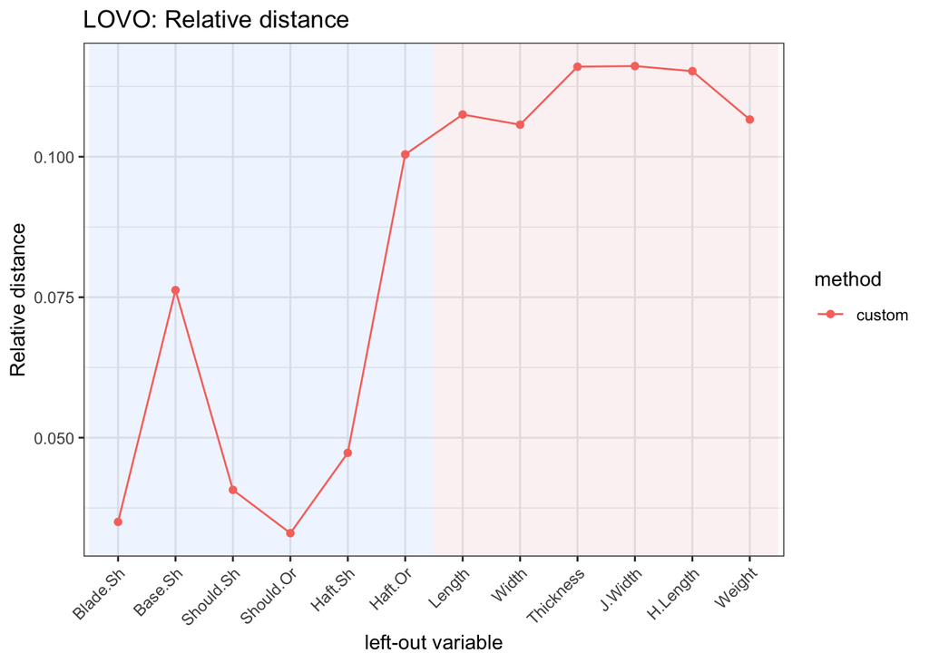

```r
# optional visual check of the updated defaults
p_rel
```

### 3.7 `compare_lovo_mdist()` sanity checks

```r
cmp_methods <- list(
  tvd_sup = lovo_method_spec(
    response = Name,
    distance_cat = "tvd",
    response_used = TRUE,
    commensurable = FALSE
  ),
  tvd_unsup = lovo_method_spec(
    response = Name,
    distance_cat = "tvd",
    response_used = FALSE,
    commensurable = FALSE
  )
)


cmp_basic <- compare_lovo_mdist(
  x = df,
  methods = cmp_methods
)


cmp_cluster <- compare_lovo_mdist(
  x = df,
  methods = cmp_methods ,
  cluster_k = 3
)

check_tbl <- tibble::tibble(
  check = character(),
  passed = logical(),
  detail = character()
)

add_check <- function(tbl, check, expr) {
  out <- tryCatch(
    {
      val <- force(expr)
      tibble::tibble(
        check = check,
        passed = isTRUE(val),
        detail = if (isTRUE(val)) "TRUE" else paste(capture.output(print(val)), collapse = " ")
      )
    },
    error = function(e) {
      tibble::tibble(
        check = check,
        passed = FALSE,
        detail = conditionMessage(e)
      )
    }
  )
  dplyr::bind_rows(tbl, out)
}

# 1. object creation
check_tbl <- add_check(
  check_tbl,
  "compare_lovo_mdist() returns MDistLOVOCompare",
  inherits(cmp_basic, "MDistLOVOCompare")
)

# 2. methods column present and correct
check_tbl <- add_check(
  check_tbl,
  "results contain expected method labels",
  setequal(as.character(unique(cmp_basic$results$method)), c("tvd_sup", "tvd_unsup"))
)

# 3. updated metric names available
check_tbl <- add_check(
  check_tbl,
  "results contain relative_distance",
  "relative_distance" %in% names(cmp_basic$results)
)

check_tbl <- add_check(
  check_tbl,
  "results contain mds_congruence",
  "mds_congruence" %in% names(cmp_basic$results)
)

# 4. backward-compatible aliases retained
check_tbl <- add_check(
  check_tbl,
  "results retain mad_normalized",
  "mad_normalized" %in% names(cmp_basic$results)
)

check_tbl <- add_check(
  check_tbl,
  "results retain cc_importance",
  "cc_importance" %in% names(cmp_basic$results)
)

# 5. aliases are equal
check_tbl <- add_check(
  check_tbl,
  "relative_distance equals mad_normalized",
  all.equal(cmp_basic$results$relative_distance, cmp_basic$results$mad_normalized)
)

check_tbl <- add_check(
  check_tbl,
  "mds_congruence equals cc_importance",
  all.equal(cmp_basic$results$mds_congruence, cmp_basic$results$cc_importance)
)

# 6. no clustering columns without cluster_k
check_tbl <- add_check(
  check_tbl,
  "no clustering columns when cluster_k is NULL",
  !any(c("ari_pam", "pam_importance", "ari_hclust", "hclust_importance") %in%
         names(cmp_basic$results))
)

# 7. clustering columns present with cluster_k
check_tbl <- add_check(
  check_tbl,
  "clustering columns added when cluster_k is supplied",
  all(c("ari_pam", "pam_importance", "ari_hclust", "hclust_importance") %in%
        names(cmp_cluster$results))
)

# 8. print/summary work
check_tbl <- add_check(
  check_tbl,
  "print() works on compare object",
  {
    capture.output(print(cmp_basic))
    TRUE
  }
)

check_tbl <- add_check(
  check_tbl,
  "summary() works on compare object",
  {
    capture.output(summary(cmp_basic))
    TRUE
  }
)

# 9. autoplot works for updated metrics
p_rel <- autoplot(cmp_basic, metric = "relative_distance")
p_mad <- autoplot(cmp_basic, metric = "mad_importance")
p_mds <- autoplot(cmp_basic, metric = "mds_congruence")

check_tbl <- add_check(
  check_tbl,
  "autoplot(relative_distance) returns ggplot",
  inherits(p_rel, "ggplot")
)

check_tbl <- add_check(
  check_tbl,
  "autoplot(mad_importance) returns ggplot",
  inherits(p_mad, "ggplot")
)

check_tbl <- add_check(
  check_tbl,
  "autoplot(mds_congruence) returns ggplot",
  inherits(p_mds, "ggplot")
)

# 10. clustering autoplot works when enabled
p_pam <- autoplot(cmp_cluster, metric = "pam_importance")
p_hclust <- autoplot(cmp_cluster, metric = "hclust_importance")

check_tbl <- add_check(
  check_tbl,
  "autoplot(pam_importance) works when clustering is enabled",
  inherits(p_pam, "ggplot")
)

check_tbl <- add_check(
  check_tbl,
  "autoplot(hclust_importance) works when clustering is enabled",
  inherits(p_hclust, "ggplot")
)

check_tbl
```

```
# A tibble: 17 × 3
   check                                                        passed detail
   <chr>                                                        <lgl>  <chr>
 1 compare_lovo_mdist() returns MDistLOVOCompare                TRUE   TRUE
 2 results contain expected method labels                       TRUE   TRUE
 3 results contain relative_distance                            TRUE   TRUE
 4 results contain mds_congruence                               TRUE   TRUE
 5 results retain mad_normalized                                TRUE   TRUE
 6 results retain cc_importance                                 TRUE   TRUE
 7 relative_distance equals mad_normalized                      TRUE   TRUE
 8 mds_congruence equals cc_importance                          TRUE   TRUE
 9 no clustering columns when cluster_k is NULL                 TRUE   TRUE
10 clustering columns added when cluster_k is supplied          TRUE   TRUE
11 print() works on compare object                              TRUE   TRUE
12 summary() works on compare object                            TRUE   TRUE
13 autoplot(relative_distance) returns ggplot                   TRUE   TRUE
14 autoplot(mad_importance) returns ggplot                      TRUE   TRUE
15 autoplot(mds_congruence) returns ggplot                      TRUE   TRUE
16 autoplot(pam_importance) works when clustering is enabled    TRUE   TRUE
17 autoplot(hclust_importance) works when clustering is enabled TRUE   TRUE
```

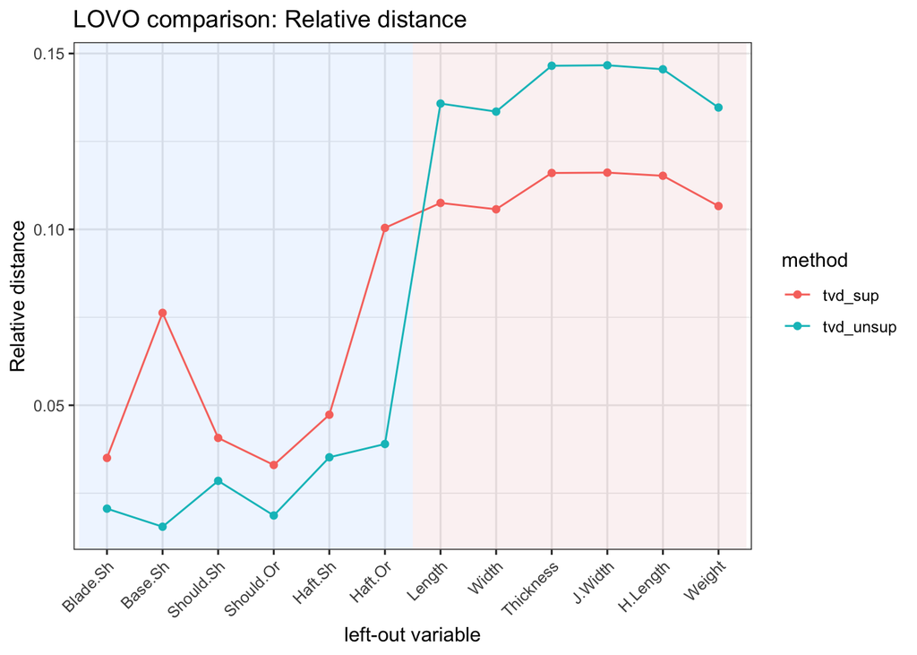

```r
# optional visual check
p_rel
```

This section verifies that the renamed metrics are present, backward-compatible aliases are retained, and the updated `print()`, `summary()`, and `autoplot()` methods behave correctly both with and without clustering diagnostics.

### 3.8 Additional LOVO questions

- Should there be a spectral clustering importance measure?
- Should LOVO default to one-cluster methods only, or to all available methods? -> cluster only if number of clusters is provided.

## 4 Downstream clustering support

### 4.1 Spectral clustering

Improve `spectral_from_dist()` so that it accepts both: - a distance matrix; - a distance object such as `mdist$distance`.

### 4.2 Built-in downstream methods

Consider expanding built-in support for: - PAM - hierarchical clustering - spectral clustering - other downstream methods using distances

### 4.3 Hierarchical clustering documentation

Document clearly which linkage is used in hierarchical clustering workflows. Current assumption: complete linkage. This should be confirmed and made explicit.

## 5 Variable weights

- Reintroduce or expand support for user-defined variable weights.
- Potential uses include:
  - emphasizing specific variables;
  - weighting continuous and categorical blocks differently;
  - randomized weighting for robustness analyses;
  - future tuning strategies for weights.

Need to clarify how this should interact with commensurability.

## 6 MCA issue

Investigate the behavior of `distance_cat = "mca"` under commensurability.

Expected: - methods whose Delta matrix is only a constant multiple of matching should collapse under commensurability, e.g.: - matching - eskin - HL - naive

Unexpected: - `mca` currently appears to collapse to commensurable matching as well.

Why this is problematic: - MCA uses marginal frequencies in its Delta matrix; - therefore, unless category distributions are exactly balanced, commensurable `mca` should not become identical to commensurable matching.

This issue needs clarification and likely a code check.

## 7 Documentation and transparency

### 7.1 Specific documentation needs

- Document clearly which distances are:
  - association-based;
  - supervised-capable;
  - independent of the response.
- Document what happens when `response` is supplied with a distance that does not use it.
- Document hierarchical clustering defaults.
- Document LOVO output and interpretation more clearly.

### 7.2 Latest points raised

**WarningImports and naming**

- For the gower preset in mdist I think that (unless loaded already) one needs to manually do library(tidymodels)
  - ✅ fixed
- For dkss, I needed to manually install kdml
- Also: dkss is now (in the paper at least) dkps. In the package this still is dkss. (TRUE and to be fixed) well the packages kdml has both

one is distance using kernel product similarity

the other is distance using kernel summation similarity

- ✅ fixed: the only implementation is now dkss

**WarningGower preset**

If I use preset=gower, it seems to do commensurable gower. That is not correct. When I add commensurable=FALSE, it seems more like the correct one. But, due to the differences between daisy and our formulations (division through q I think), this sometimes for lovo) tricky. I get back to that.

- ✅ fixed:

I added a flag `gower_average` such that when `gower_average=TRUE` (the default) then `mdist(x,preset="gower")` is the same as `cluster::daisy(x, metric="gower")`.

**Importantpresets override other arguments**

For all other (not unbiased) presets, the “commensurable” input appears to be ignored. This is good. In fact, I think we should also do this for gower (and even for the unbiased ones: if a preset is used, you cannot edit the inputs (scalings, distances, commensurability: all fixed according to the settings of the preset).

- ✅ DONE

**NoteGower/Daisy lovo vs Gower/custom lovo:**

As a result of 4) (presets do not allow modifications). If one wants to make gower commensurable, you have to use custom and do: cont_scaling=“range”, distance_cat=“matching”, commensurable=TRUE This is fine for me. But: Doing gower in this way is then not the same as daisy gower. It has the factor q (#variables) in there. Again, I think this is not a problem (and also, since for all our distances we do not have this /q, it seems consistent. There is however one odd thing when I consider the preset gower and “our” gower when it comes to variable importances. That is, in the lovo results: If I do:

```r
meths<-list(g = list(preset="gower", commensurable=FALSE),   g2 = list(scaling_cont="range", distance_cat="matching", commensurable=FALSE))
}
# And: I added commensurable FALSE for gower to get it to not give unbiased results; but this should be fixed so that it is not necessary to add this when using the preset.

 So: g = daisy gower (I think) . g2 is “our” gower.
# Then: running lovo_cmp on df (minus first column but that is not important now):
```

```r
lovo_cmp <- compare_lovo_mdist(df[,-1],methods = meths)
autoplot(lovo_cmp)
}
```

Oddly, I get different results for lovo. And: not trivially so (I mean: not constant inflated/deflated). I have no explanation for this…

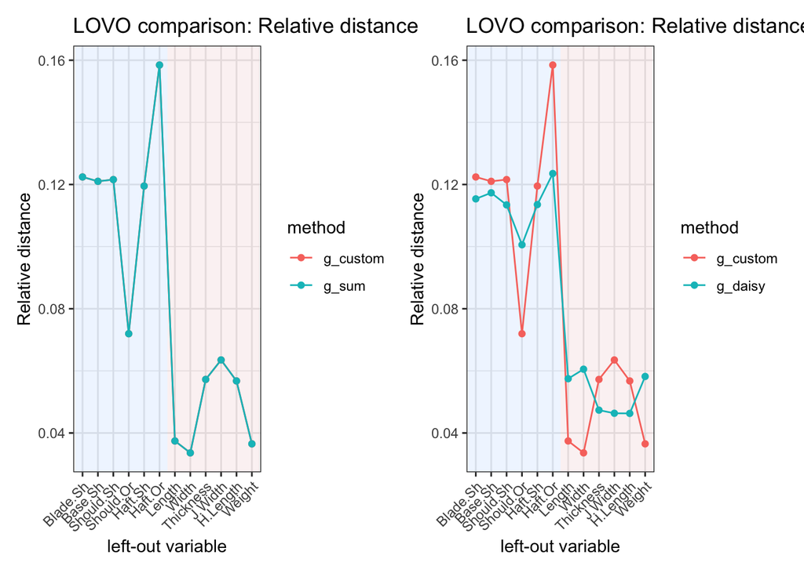

```r
meths <- list(
  g_daisy = list(
    preset = "gower"
  ),
  g_sum = list(
    preset = "gower",
    gower_average = FALSE
  ),
  g_custom = list(
    preset = "custom",
    distance_cont = "manhattan",
    scaling_cont = "range",
    distance_cat = "matching",
    commensurable = FALSE
  )
)



lovo_cmp <- compare_lovo_mdist(df[,-1], methods = meths[c("g_custom","g_sum")])
lovo_cmp2 <- compare_lovo_mdist(df[,-1], methods = meths[c("g_custom","g_daisy")])
library(patchwork)
autoplot(lovo_cmp)|autoplot(lovo_cmp2)
```